# Optimal Treatment Analysis

## Outcome Variable

**Outcome Variable:** whz

## Predictor Variables

**Intervention Variable:** month

**Adjustment Set:**

unadjusted

## Stratifying Variables

The analysis was stratified on these variable(s):

- agecat
- studyid
- country

## Data Summary

| agecat | studyid | country | month | n_cell | n |
| --- | --- | --- | --- | --- | --- |
| Birth | CMC-V-BCS-2002 | INDIA | 1 | 9 | 86 |
| Birth | CMC-V-BCS-2002 | INDIA | 2 | 1 | 86 |
| Birth | CMC-V-BCS-2002 | INDIA | 3 | 7 | 86 |
| Birth | CMC-V-BCS-2002 | INDIA | 4 | 9 | 86 |
| Birth | CMC-V-BCS-2002 | INDIA | 5 | 9 | 86 |
| Birth | CMC-V-BCS-2002 | INDIA | 6 | 10 | 86 |
| Birth | CMC-V-BCS-2002 | INDIA | 7 | 7 | 86 |
| Birth | CMC-V-BCS-2002 | INDIA | 8 | 4 | 86 |
| Birth | CMC-V-BCS-2002 | INDIA | 9 | 8 | 86 |
| Birth | CMC-V-BCS-2002 | INDIA | 10 | 8 | 86 |
| Birth | CMC-V-BCS-2002 | INDIA | 11 | 11 | 86 |
| Birth | CMC-V-BCS-2002 | INDIA | 12 | 3 | 86 |
| Birth | CMIN | BANGLADESH | 1 | 0 | 19 |
| Birth | CMIN | BANGLADESH | 2 | 4 | 19 |
| Birth | CMIN | BANGLADESH | 3 | 2 | 19 |
| Birth | CMIN | BANGLADESH | 4 | 0 | 19 |
| Birth | CMIN | BANGLADESH | 5 | 3 | 19 |
| Birth | CMIN | BANGLADESH | 6 | 0 | 19 |
| Birth | CMIN | BANGLADESH | 7 | 0 | 19 |
| Birth | CMIN | BANGLADESH | 8 | 5 | 19 |
| Birth | CMIN | BANGLADESH | 9 | 2 | 19 |
| Birth | CMIN | BANGLADESH | 10 | 1 | 19 |
| Birth | CMIN | BANGLADESH | 11 | 2 | 19 |
| Birth | CMIN | BANGLADESH | 12 | 0 | 19 |
| Birth | CONTENT | PERU | 1 | 0 | 2 |
| Birth | CONTENT | PERU | 2 | 0 | 2 |
| Birth | CONTENT | PERU | 3 | 0 | 2 |
| Birth | CONTENT | PERU | 4 | 0 | 2 |
| Birth | CONTENT | PERU | 5 | 2 | 2 |
| Birth | CONTENT | PERU | 6 | 0 | 2 |

[output cut: 774 more lines]

The following strata were considered:

- agecat: 24 months, studyid: CMC-V-BCS-2002, country: INDIA
- agecat: 24 months, studyid: CMIN, country: BANGLADESH
- agecat: 24 months, studyid: CONTENT, country: PERU
- agecat: 24 months, studyid: EE, country: PAKISTAN
- agecat: 24 months, studyid: GMS-Nepal, country: NEPAL
- agecat: 24 months, studyid: IRC, country: INDIA
- agecat: 24 months, studyid: JiVitA-3, country: BANGLADESH
- agecat: 24 months, studyid: JiVitA-4, country: BANGLADESH
- agecat: 24 months, studyid: Keneba, country: GAMBIA
- agecat: 24 months, studyid: LCNI-5, country: MALAWI
- agecat: 24 months, studyid: MAL-ED, country: BANGLADESH
- agecat: 24 months, studyid: MAL-ED, country: BRAZIL
- agecat: 24 months, studyid: MAL-ED, country: INDIA
- agecat: 24 months, studyid: MAL-ED, country: NEPAL
- agecat: 24 months, studyid: MAL-ED, country: PERU
- agecat: 24 months, studyid: MAL-ED, country: SOUTH AFRICA
- agecat: 24 months, studyid: MAL-ED, country: TANZANIA, UNITED REPUBLIC OF
- agecat: 24 months, studyid: NIH-Birth, country: BANGLADESH
- agecat: 24 months, studyid: PROBIT, country: BELARUS
- agecat: 24 months, studyid: TanzaniaChild2, country: TANZANIA, UNITED REPUBLIC OF
- agecat: 24 months, studyid: ZVITAMBO, country: ZIMBABWE
- agecat: 6 months, studyid: CMC-V-BCS-2002, country: INDIA
- agecat: 6 months, studyid: CMIN, country: BANGLADESH
- agecat: 6 months, studyid: CONTENT, country: PERU
- agecat: 6 months, studyid: EE, country: PAKISTAN
- agecat: 6 months, studyid: GMS-Nepal, country: NEPAL
- agecat: 6 months, studyid: Guatemala BSC, country: GUATEMALA
- agecat: 6 months, studyid: IRC, country: INDIA
- agecat: 6 months, studyid: JiVitA-3, country: BANGLADESH
- agecat: 6 months, studyid: JiVitA-4, country: BANGLADESH
- agecat: 6 months, studyid: Keneba, country: GAMBIA
- agecat: 6 months, studyid: LCNI-5, country: MALAWI
- agecat: 6 months, studyid: MAL-ED, country: BANGLADESH
- agecat: 6 months, studyid: MAL-ED, country: BRAZIL
- agecat: 6 months, studyid: MAL-ED, country: INDIA
- agecat: 6 months, studyid: MAL-ED, country: NEPAL
- agecat: 6 months, studyid: MAL-ED, country: PERU
- agecat: 6 months, studyid: MAL-ED, country: SOUTH AFRICA
- agecat: 6 months, studyid: MAL-ED, country: TANZANIA, UNITED REPUBLIC OF
- agecat: 6 months, studyid: NIH-Birth, country: BANGLADESH
- agecat: 6 months, studyid: PROBIT, country: BELARUS
- agecat: 6 months, studyid: ResPak, country: PAKISTAN
- agecat: 6 months, studyid: SAS-CompFeed, country: INDIA
- agecat: 6 months, studyid: SAS-FoodSuppl, country: INDIA
- agecat: 6 months, studyid: TanzaniaChild2, country: TANZANIA, UNITED REPUBLIC OF
- agecat: 6 months, studyid: ZVITAMBO, country: ZIMBABWE
- agecat: Birth, studyid: CMC-V-BCS-2002, country: INDIA
- agecat: Birth, studyid: CMIN, country: BANGLADESH
- agecat: Birth, studyid: CONTENT, country: PERU
- agecat: Birth, studyid: EE, country: PAKISTAN
- agecat: Birth, studyid: GMS-Nepal, country: NEPAL
- agecat: Birth, studyid: IRC, country: INDIA
- agecat: Birth, studyid: JiVitA-3, country: BANGLADESH
- agecat: Birth, studyid: JiVitA-4, country: BANGLADESH
- agecat: Birth, studyid: Keneba, country: GAMBIA
- agecat: Birth, studyid: MAL-ED, country: BANGLADESH
- agecat: Birth, studyid: MAL-ED, country: BRAZIL
- agecat: Birth, studyid: MAL-ED, country: INDIA
- agecat: Birth, studyid: MAL-ED, country: NEPAL
- agecat: Birth, studyid: MAL-ED, country: PERU
- agecat: Birth, studyid: MAL-ED, country: SOUTH AFRICA
- agecat: Birth, studyid: MAL-ED, country: TANZANIA, UNITED REPUBLIC OF
- agecat: Birth, studyid: NIH-Birth, country: BANGLADESH
- agecat: Birth, studyid: PROBIT, country: BELARUS
- agecat: Birth, studyid: ResPak, country: PAKISTAN
- agecat: Birth, studyid: SAS-CompFeed, country: INDIA
- agecat: Birth, studyid: ZVITAMBO, country: ZIMBABWE

### Dropped Strata

Some strata were dropped due to rare outcomes:

- agecat: Birth, studyid: CMC-V-BCS-2002, country: INDIA
- agecat: Birth, studyid: CMIN, country: BANGLADESH
- agecat: Birth, studyid: CONTENT, country: PERU
- agecat: Birth, studyid: EE, country: PAKISTAN
- agecat: Birth, studyid: GMS-Nepal, country: NEPAL
- agecat: Birth, studyid: JiVitA-4, country: BANGLADESH
- agecat: Birth, studyid: MAL-ED, country: BRAZIL
- agecat: Birth, studyid: MAL-ED, country: INDIA
- agecat: Birth, studyid: MAL-ED, country: NEPAL
- agecat: Birth, studyid: MAL-ED, country: SOUTH AFRICA
- agecat: Birth, studyid: MAL-ED, country: TANZANIA, UNITED REPUBLIC OF
- agecat: Birth, studyid: ResPak, country: PAKISTAN
- agecat: 6 months, studyid: CMIN, country: BANGLADESH
- agecat: 6 months, studyid: EE, country: PAKISTAN
- agecat: 6 months, studyid: GMS-Nepal, country: NEPAL
- agecat: 6 months, studyid: ResPak, country: PAKISTAN
- agecat: 6 months, studyid: SAS-FoodSuppl, country: INDIA
- agecat: 24 months, studyid: CMIN, country: BANGLADESH
- agecat: 24 months, studyid: CONTENT, country: PERU
- agecat: 24 months, studyid: EE, country: PAKISTAN
- agecat: 24 months, studyid: GMS-Nepal, country: NEPAL
- agecat: 24 months, studyid: TanzaniaChild2, country: TANZANIA, UNITED REPUBLIC OF
- agecat: 24 months, studyid: ZVITAMBO, country: ZIMBABWE

## Methods Detail

We’re interested in the causal parameters $E[Y_a]$ for all values of $a \in \mathcal{A}$. These parameters represent the mean outcome if, possibly contrary to fact, we intervened to set all units to have $A=a$. Under the randomization and positivity assumptions, these are identified by the statistical parameters $\psi_a=E_W[E_{Y|A,W}(Y|A=a,W)]$. In addition, we’re interested in the mean of $Y$, $E[Y]$ under no intervention (the observed mean). We will estimate these parameters by using SuperLearner to fit the relevant likelihood factors – $E_{Y|A,W}(Y|A=a,W)$ and $p(A=a|W)$, and then updating our likelihood fit using a joint TMLE.

For unadjusted analyses ($W=\{\}$), initial likelihoods were estimated using Lrnr_glm to estimate the simple $E(Y|A)$ and Lrnr_mean to estimate $p(A)$. For adjusted analyses, a small library containing Lrnr_glmnet, Lrnr_xgboost, and Lrnr_mean was used.

# Results Detail

## Results Plots

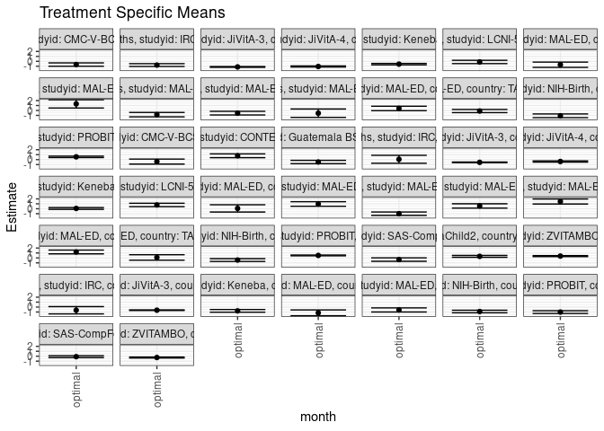

## Results Table

### Parameter: TSM

| agecat | studyid | country | intervention_level | baseline_level | estimate | ci_lower | ci_upper |
| --- | --- | --- | --- | --- | --- | --- | --- |
| Birth | IRC | INDIA | optimal | observed | -0.6440844 | -1.3798035 | 0.0916347 |
| Birth | JiVitA-3 | BANGLADESH | optimal | observed | -0.6340098 | -0.6916102 | -0.5764093 |
| Birth | Keneba | GAMBIA | optimal | observed | -0.7695628 | -1.0449645 | -0.4941610 |
| Birth | MAL-ED | BANGLADESH | optimal | observed | -1.1709124 | -1.7598186 | -0.5820062 |
| Birth | MAL-ED | PERU | optimal | observed | -0.5838324 | -1.0007846 | -0.1668802 |
| Birth | NIH-Birth | BANGLADESH | optimal | observed | -0.9051155 | -1.1654912 | -0.6447399 |
| Birth | PROBIT | BELARUS | optimal | observed | -1.0185829 | -1.2989683 | -0.7381974 |
| Birth | SAS-CompFeed | INDIA | optimal | observed | -0.0941808 | -0.2891424 | 0.1007809 |
| Birth | ZVITAMBO | ZIMBABWE | optimal | observed | -0.2646744 | -0.3608102 | -0.1685386 |
| 6 months | CMC-V-BCS-2002 | INDIA | optimal | observed | -0.3982492 | -0.9028959 | 0.1063975 |
| 6 months | CONTENT | PERU | optimal | observed | 0.7778788 | 0.3926947 | 1.1630629 |
| 6 months | Guatemala BSC | GUATEMALA | optimal | observed | -0.4885252 | -0.8269609 | -0.1500896 |
| 6 months | IRC | INDIA | optimal | observed | 0.0655018 | -0.7375533 | 0.8685569 |
| 6 months | JiVitA-3 | BANGLADESH | optimal | observed | -0.5532127 | -0.6223363 | -0.4840891 |
| 6 months | JiVitA-4 | BANGLADESH | optimal | observed | -0.3827400 | -0.5103516 | -0.2551283 |
| 6 months | Keneba | GAMBIA | optimal | observed | 0.0622014 | -0.1158594 | 0.2402622 |
| 6 months | LCNI-5 | MALAWI | optimal | observed | 0.7666497 | 0.4233017 | 1.1099977 |
| 6 months | MAL-ED | BANGLADESH | optimal | observed | 0.0747852 | -0.6622814 | 0.8118519 |
| 6 months | MAL-ED | BRAZIL | optimal | observed | 0.9650660 | 0.5051634 | 1.4249685 |
| 6 months | MAL-ED | INDIA | optimal | observed | -0.9989944 | -1.3391849 | -0.6588040 |
| 6 months | MAL-ED | NEPAL | optimal | observed | 0.5701478 | 0.1324263 | 1.0078694 |
| 6 months | MAL-ED | PERU | optimal | observed | 1.4683121 | 0.9604622 | 1.9761620 |
| 6 months | MAL-ED | SOUTH AFRICA | optimal | observed | 1.1997727 | 0.8155549 | 1.5839906 |
| 6 months | MAL-ED | TANZANIA, UNITED REPUBLIC OF | optimal | observed | 0.0904496 | -0.4630220 | 0.6439212 |
| 6 months | NIH-Birth | BANGLADESH | optimal | observed | -0.4334682 | -0.7137451 | -0.1531913 |
| 6 months | PROBIT | BELARUS | optimal | observed | 0.5005142 | 0.4183833 | 0.5826452 |
| 6 months | SAS-CompFeed | INDIA | optimal | observed | -0.3378347 | -0.6848812 | 0.0092117 |
| 6 months | TanzaniaChild2 | TANZANIA, UNITED REPUBLIC OF | optimal | observed | 0.3150285 | 0.1237502 | 0.5063067 |
| 6 months | ZVITAMBO | ZIMBABWE | optimal | observed | 0.3696202 | 0.2732542 | 0.4659861 |
| 24 months | CMC-V-BCS-2002 | INDIA | optimal | observed | -0.6566695 | -0.9975365 | -0.3158024 |
| 24 months | IRC | INDIA | optimal | observed | -0.7619589 | -1.0490303 | -0.4748875 |
| 24 months | JiVitA-3 | BANGLADESH | optimal | observed | -1.1363197 | -1.2081991 | -1.0644403 |
| 24 months | JiVitA-4 | BANGLADESH | optimal | observed | -1.0497097 | -1.1556230 | -0.9437964 |
| 24 months | Keneba | GAMBIA | optimal | observed | -0.5688508 | -0.7125364 | -0.4251652 |
| 24 months | LCNI-5 | MALAWI | optimal | observed | -0.1334189 | -0.4660218 | 0.1991840 |
| 24 months | MAL-ED | BANGLADESH | optimal | observed | -0.6934073 | -1.2262962 | -0.1605184 |
| 24 months | MAL-ED | BRAZIL | optimal | observed | 1.3285098 | 0.4957097 | 2.1613099 |
| 24 months | MAL-ED | INDIA | optimal | observed | -0.8432460 | -1.2848067 | -0.4016853 |
| 24 months | MAL-ED | NEPAL | optimal | observed | -0.5433342 | -0.9116267 | -0.1750417 |
| 24 months | MAL-ED | PERU | optimal | observed | -0.5551769 | -1.4043439 | 0.2939901 |
| 24 months | MAL-ED | SOUTH AFRICA | optimal | observed | 0.4091835 | -0.0408122 | 0.8591793 |
| 24 months | MAL-ED | TANZANIA, UNITED REPUBLIC OF | optimal | observed | -0.1157557 | -0.4371872 | 0.2056758 |
| 24 months | NIH-Birth | BANGLADESH | optimal | observed | -1.0810744 | -1.4597937 | -0.7023551 |
| 24 months | PROBIT | BELARUS | optimal | observed | 0.5583776 | 0.4136918 | 0.7030633 |

### Parameter: E(Y)

| agecat | studyid | country | intervention_level | baseline_level | estimate | ci_lower | ci_upper |
| --- | --- | --- | --- | --- | --- | --- | --- |
| Birth | IRC | INDIA | observed | observed | -1.0105831 | -1.1973019 | -0.8238643 |
| Birth | JiVitA-3 | BANGLADESH | observed | observed | -0.7778272 | -0.7968313 | -0.7588232 |
| Birth | Keneba | GAMBIA | observed | observed | -1.2349454 | -1.2972413 | -1.1726496 |
| Birth | MAL-ED | BANGLADESH | observed | observed | -0.9418605 | -1.0869834 | -0.7967375 |
| Birth | MAL-ED | PERU | observed | observed | -0.0520175 | -0.1725298 | 0.0684947 |
| Birth | NIH-Birth | BANGLADESH | observed | observed | -1.3499217 | -1.4444634 | -1.2553801 |
| Birth | PROBIT | BELARUS | observed | observed | -1.1491782 | -1.3593933 | -0.9389630 |
| Birth | SAS-CompFeed | INDIA | observed | observed | -0.6700453 | -0.8474950 | -0.4925957 |
| Birth | ZVITAMBO | ZIMBABWE | observed | observed | -0.5154897 | -0.5413479 | -0.4896314 |
| 6 months | CMC-V-BCS-2002 | INDIA | observed | observed | -0.5026766 | -0.6536848 | -0.3516685 |
| 6 months | CONTENT | PERU | observed | observed | 1.0644279 | 0.9468682 | 1.1819876 |
| 6 months | Guatemala BSC | GUATEMALA | observed | observed | -0.0840134 | -0.1945572 | 0.0265305 |
| 6 months | IRC | INDIA | observed | observed | -0.5989297 | -0.7344491 | -0.4634104 |
| 6 months | JiVitA-3 | BANGLADESH | observed | observed | -0.5935161 | -0.6130518 | -0.5739805 |
| 6 months | JiVitA-4 | BANGLADESH | observed | observed | -0.3898055 | -0.4270507 | -0.3525603 |
| 6 months | Keneba | GAMBIA | observed | observed | -0.1846038 | -0.2354782 | -0.1337293 |
| 6 months | LCNI-5 | MALAWI | observed | observed | 0.4499404 | 0.3788501 | 0.5210308 |
| 6 months | MAL-ED | BANGLADESH | observed | observed | -0.1376763 | -0.2664642 | -0.0088885 |
| 6 months | MAL-ED | BRAZIL | observed | observed | 0.9720774 | 0.8078144 | 1.1363403 |
| 6 months | MAL-ED | INDIA | observed | observed | -0.7079979 | -0.8344175 | -0.5815783 |
| 6 months | MAL-ED | NEPAL | observed | observed | 0.1104308 | -0.0208643 | 0.2417259 |
| 6 months | MAL-ED | PERU | observed | observed | 1.0528816 | 0.9313005 | 1.1744626 |
| 6 months | MAL-ED | SOUTH AFRICA | observed | observed | 0.5421785 | 0.3900443 | 0.6943126 |
| 6 months | MAL-ED | TANZANIA, UNITED REPUBLIC OF | observed | observed | 0.5362213 | 0.4049390 | 0.6675036 |
| 6 months | NIH-Birth | BANGLADESH | observed | observed | -0.4474038 | -0.5378167 | -0.3569909 |
| 6 months | PROBIT | BELARUS | observed | observed | 0.5741099 | 0.5141290 | 0.6340908 |
| 6 months | SAS-CompFeed | INDIA | observed | observed | -0.6657084 | -0.8024377 | -0.5289791 |
| 6 months | TanzaniaChild2 | TANZANIA, UNITED REPUBLIC OF | observed | observed | 0.0809332 | 0.0282644 | 0.1336020 |
| 6 months | ZVITAMBO | ZIMBABWE | observed | observed | 0.3105514 | 0.2848767 | 0.3362262 |
| 24 months | CMC-V-BCS-2002 | INDIA | observed | observed | -0.5571505 | -0.6585247 | -0.4557763 |
| 24 months | IRC | INDIA | observed | observed | -0.7458150 | -0.8368180 | -0.6548120 |
| 24 months | JiVitA-3 | BANGLADESH | observed | observed | -1.2978031 | -1.3210763 | -1.2745298 |
| 24 months | JiVitA-4 | BANGLADESH | observed | observed | -1.2231088 | -1.2549632 | -1.1912543 |
| 24 months | Keneba | GAMBIA | observed | observed | -0.8099290 | -0.8570608 | -0.7627972 |
| 24 months | LCNI-5 | MALAWI | observed | observed | -0.0477709 | -0.1296526 | 0.0341109 |
| 24 months | MAL-ED | BANGLADESH | observed | observed | -0.8192925 | -0.9412667 | -0.6973182 |
| 24 months | MAL-ED | BRAZIL | observed | observed | 0.4626233 | 0.2567495 | 0.6684971 |
| 24 months | MAL-ED | INDIA | observed | observed | -0.9516520 | -1.0670654 | -0.8362385 |
| 24 months | MAL-ED | NEPAL | observed | observed | -0.3749123 | -0.4886073 | -0.2612173 |
| 24 months | MAL-ED | PERU | observed | observed | 0.1111982 | -0.0118399 | 0.2342362 |
| 24 months | MAL-ED | SOUTH AFRICA | observed | observed | 0.4090301 | 0.2879441 | 0.5301161 |
| 24 months | MAL-ED | TANZANIA, UNITED REPUBLIC OF | observed | observed | 0.0547975 | -0.0703378 | 0.1799328 |
| 24 months | NIH-Birth | BANGLADESH | observed | observed | -0.9115790 | -1.0095022 | -0.8136559 |
| 24 months | PROBIT | BELARUS | observed | observed | 0.6981406 | 0.5843775 | 0.8119038 |

### Parameter: PAR

| agecat | studyid | country | intervention_level | baseline_level | estimate | ci_lower | ci_upper |
| --- | --- | --- | --- | --- | --- | --- | --- |
| Birth | IRC | INDIA | optimal | observed | -0.3664987 | -1.0675774 | 0.3345801 |
| Birth | JiVitA-3 | BANGLADESH | optimal | observed | -0.1438175 | -0.1968223 | -0.0908126 |
| Birth | Keneba | GAMBIA | optimal | observed | -0.4653827 | -0.7319944 | -0.1987710 |
| Birth | MAL-ED | BANGLADESH | optimal | observed | 0.2290520 | -0.3267612 | 0.7848651 |
| Birth | MAL-ED | PERU | optimal | observed | 0.5318148 | 0.1274137 | 0.9362159 |
| Birth | NIH-Birth | BANGLADESH | optimal | observed | -0.4448062 | -0.6998062 | -0.1898062 |
| Birth | PROBIT | BELARUS | optimal | observed | -0.1305953 | -0.2955232 | 0.0343326 |
| Birth | SAS-CompFeed | INDIA | optimal | observed | -0.5758646 | -0.7847183 | -0.3670108 |
| Birth | ZVITAMBO | ZIMBABWE | optimal | observed | -0.2508153 | -0.3433179 | -0.1583127 |
| 6 months | CMC-V-BCS-2002 | INDIA | optimal | observed | -0.1044274 | -0.5843576 | 0.3755027 |
| 6 months | CONTENT | PERU | optimal | observed | 0.2865491 | -0.1019855 | 0.6750837 |
| 6 months | Guatemala BSC | GUATEMALA | optimal | observed | 0.4045119 | 0.0796668 | 0.7293569 |
| 6 months | IRC | INDIA | optimal | observed | -0.6644316 | -1.4424389 | 0.1135758 |
| 6 months | JiVitA-3 | BANGLADESH | optimal | observed | -0.0403034 | -0.1065863 | 0.0259795 |
| 6 months | JiVitA-4 | BANGLADESH | optimal | observed | -0.0070655 | -0.1350050 | 0.1208739 |
| 6 months | Keneba | GAMBIA | optimal | observed | -0.2468052 | -0.4187036 | -0.0749068 |
| 6 months | LCNI-5 | MALAWI | optimal | observed | -0.3167093 | -0.6531906 | 0.0197719 |
| 6 months | MAL-ED | BANGLADESH | optimal | observed | -0.2124616 | -0.9286310 | 0.5037079 |
| 6 months | MAL-ED | BRAZIL | optimal | observed | 0.0070114 | -0.4513193 | 0.4653421 |
| 6 months | MAL-ED | INDIA | optimal | observed | 0.2909966 | -0.0425318 | 0.6245250 |
| 6 months | MAL-ED | NEPAL | optimal | observed | -0.4597170 | -0.8836988 | -0.0357353 |
| 6 months | MAL-ED | PERU | optimal | observed | -0.4154306 | -0.8992452 | 0.0683840 |
| 6 months | MAL-ED | SOUTH AFRICA | optimal | observed | -0.6575943 | -1.0235938 | -0.2915947 |
| 6 months | MAL-ED | TANZANIA, UNITED REPUBLIC OF | optimal | observed | 0.4457717 | -0.0868534 | 0.9783969 |
| 6 months | NIH-Birth | BANGLADESH | optimal | observed | -0.0139356 | -0.2878879 | 0.2600168 |
| 6 months | PROBIT | BELARUS | optimal | observed | 0.0735957 | 0.0116520 | 0.1355394 |
| 6 months | SAS-CompFeed | INDIA | optimal | observed | -0.3278737 | -0.5557358 | -0.1000116 |
| 6 months | TanzaniaChild2 | TANZANIA, UNITED REPUBLIC OF | optimal | observed | -0.2340953 | -0.4190925 | -0.0490981 |
| 6 months | ZVITAMBO | ZIMBABWE | optimal | observed | -0.0590687 | -0.1504935 | 0.0323561 |
| 24 months | CMC-V-BCS-2002 | INDIA | optimal | observed | 0.0995189 | -0.2314567 | 0.4304945 |
| 24 months | IRC | INDIA | optimal | observed | 0.0161439 | -0.2619549 | 0.2942427 |
| 24 months | JiVitA-3 | BANGLADESH | optimal | observed | -0.1614834 | -0.2303066 | -0.0926602 |
| 24 months | JiVitA-4 | BANGLADESH | optimal | observed | -0.1733991 | -0.2766410 | -0.0701572 |
| 24 months | Keneba | GAMBIA | optimal | observed | -0.2410782 | -0.3792622 | -0.1028941 |
| 24 months | LCNI-5 | MALAWI | optimal | observed | 0.0856480 | -0.2396367 | 0.4109328 |
| 24 months | MAL-ED | BANGLADESH | optimal | observed | -0.1258852 | -0.6346988 | 0.3829285 |
| 24 months | MAL-ED | BRAZIL | optimal | observed | -0.8658865 | -1.6842696 | -0.0475035 |
| 24 months | MAL-ED | INDIA | optimal | observed | -0.1084060 | -0.5289587 | 0.3121467 |
| 24 months | MAL-ED | NEPAL | optimal | observed | 0.1684219 | -0.1888668 | 0.5257107 |
| 24 months | MAL-ED | PERU | optimal | observed | 0.6663751 | -0.1495965 | 1.4823467 |
| 24 months | MAL-ED | SOUTH AFRICA | optimal | observed | -0.0001534 | -0.4319617 | 0.4316549 |
| 24 months | MAL-ED | TANZANIA, UNITED REPUBLIC OF | optimal | observed | 0.1705532 | -0.1415601 | 0.4826665 |
| 24 months | NIH-Birth | BANGLADESH | optimal | observed | 0.1694954 | -0.1928545 | 0.5318452 |
| 24 months | PROBIT | BELARUS | optimal | observed | 0.1397631 | 0.0018325 | 0.2776937 |